# Web Scraping

15 de dezembro de 2018

## Conteúdo

- Introdução
- HTML
- rvest
- RSelenium
- Encerramento

## Introdução

- Pacotes
- O que é web scraping?

## Pacotes

- Essenciais
  - rvest
  - RSelenium
- Outros
  - stringr
  - dplyr

A documentação dos pacotes encontra-se na pasta da apresentação.

## O que é web scraping ?

web scraping é uma técnica de coleta online que por meio de processos automatizados realiza uma *raspagem* (scraping) de uma página da web, estruturando informações contidas no site.

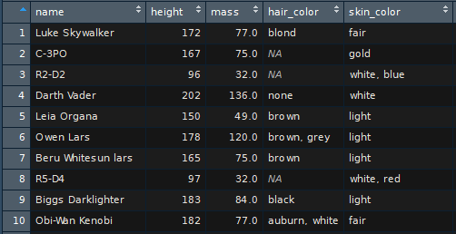

Dados estruturados

[figure not shown]

Dados não estruturados

## robots.txt

robots.txt é uma forma de sabermos onde o proprietário do site nos permite fazer scraping. Atualmente, grande parte dos sites já o possuem. Podemos consultá-lo apenas adicionando `/robots.txt` no final da url.  
Exemplo: http://www.amazon.com.br/robots.txt , ao clicar no link poderemos ver o robots.txt da página da Amazon.

## HTML

- Estruturas (nodes)
- Inspecionar Elemento
- xpath

## Estruturas (nodes)

- [Tags](https://html.com/tags/)
  - título: `<title> ... </title>`
  - parágrafo de texto: `<p> ... </p>`
  - blocos: `<div> ... </div>`
  - tabela: `<table> ... </table>`
  - hiperlink (âncora): `<a> ... </a>`
- Class
  - exemplo: `<p class = 'CLASSE'> ... </p>`
- ID
  - exemplo: `<p id = 'ID'> ... </p>`

## Inspecionar Elemento

Podemos inspecionar os elementos de uma página clicando com o botão direito do mouse e acessando a opção **Inspecionar Elemento**.

[figure not shown]

## Inspeção

A seguinte janela aparecerá.

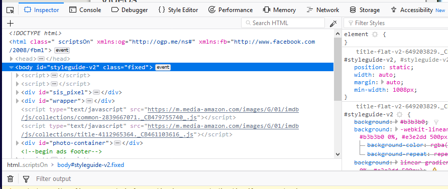

## xpath

O xpath assim como tag, class e id é uma forma de localizar elementos de uma página da web.  
Em **Inspecionar Elemento** clique com o botão direito na parte desejada e selecione `copiar -> xpath` (pode variar de navegador para navegador).

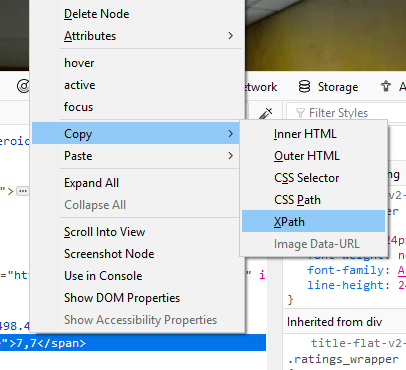

Copiando o xpath de um node

## Vantagens e desvantagens

- Vantagens
  - Fácil utilização
  - As vezes é a única alternativa ou a mais simples.
- Desvantagens
  - É um endereço fixo, se alguma coisa mudar no site todos eu código pode ser perdido.
  - Não é universal para todos os navegadores.

## Pacotes

- rvest
- RSelenium

## rvest

Principais funções.

- `read_html()`
- `html_node()`
- `html_nodes()`
- `html_text()`
- `html_attr()`
- `html_table()`

[figure not shown]

## `read_html()`

A função `read_html()` lê arquivos em html de forma similiar a um `read_csv()`, que lê arquivos no formato `.csv`.

- `HTML <- read_html(https://www.wikipedia.org/)` aqui estamos lendo a página inicial do Wikipedia e armazenando em um objeto.

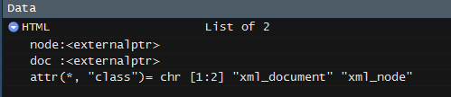

O seguinte objeto foi criado

## `html_node()` e `html_nodes()`

Essas funções extraem partes de um arquivo HTML lido com o `read_html()`. O(s) node(s) que buscamos devem ser passado(s) como uma string, da seguinte forma.

Vamos supor que ao objeto `HTML` está atribuído um arquivo html usando a função `read_html()`.

- `html_node(HTML, 'a')`, extrai apenas uma parte com a tag `a`.  
- `html_nodes(HTML, '.title')`, extrai todas as partes que possuem a class `title`, em caso de class devemos colocar `.` antes do nome da classe.  
- `html_node(HTML, #price)`, extrai apenas uma parte com o id `price`, em caso de id devemos colocar `#` antes do nome do id.

Podemos ainda buscar por mais de uma parte, exemplo:  
- `html_node(HTML, '.price li')`, estamos extraindo apenas uma parte com a tag `li` que esta "dentro" da class `price`.

## `html_text()`, `html_attr()` e `html_table()`

Esse conjunto de funções nos permite efitivamente coletar as informções dos nodes.

- `html_text()` coleta o texto daquele node.
- `html_attr()` coleta um atributo do node, por exemplo `href`.
- `html_table()` coleta uma tabela.

## Exercício (rvest)

## Exercício (rvest)

Com o que vimos até agora faça uma coleta simples no site do [IMDB](https://www.imdb.com/) de algum filme que queira e colete as seguintes informações:

- Título
- Sinopse
- Ano
- Avaliação
- Link para a imagem do poster.  
  Dica: use a função `html_attr()`

Tente não usar o xpath.

## RSelenium

**Por que usar o RSelenium?**  
Nem sempre sites não são feitos apenas em **html**, alguns possuem aplicativos interativos feitos em outras linguagens, como por exemplo **JavaScript**. Assim, precisaremos emular um navegador automatizado para interagir com a página web e coletar as informações desejadas e para isso usaremos o `Selenium`.

## Funções

Principais funções.

- `rsDriver()`
- `navigate()`
- `goBack()`
- `goForward()`
- `refresh()`
- `findElement()`
- `findElements()`
- `clickElement()`
- `sendKeysToElement()`

[figure not shown]

## `rsDriver()`

Inicia o navegador automatizado, o navegador *default* é o Chrome mas possuímos 2 outras opções, Firefox e phantomJS.  
Utilização:  
- `rD <- rsDriver(browser = 'firefox')` incializa o Firefox e armazena em um objeto.  
- `remDr <- rD$client` remDr é o objeto que será o cliente do servidor, ou seja, ele é responsável por enviar as requisições.

`remDr` = *Remote Driver*

## `navigate()`, `goBack()`, `goForward()` e `refresh()`

- `navigate()` navega até a url desejada. Utilização. `remDr$navigate('http://www.google.com.br/')` navega até a página inicial do google.
- `goBack()` volta para a página anterior do navegador. Utilização, `remDr$goBack()`
- `goForward()` avança para a página seguinte do navegador. Utilização, `remDr$goForward()`
- `refresh()` atualiza a página do navegador. Utilização, `remDr$refresh()`

## `findElement()` e `findElements()`

Essas funções são similares as funções `html_node()` e `html_nodes()`, respectivamente.  
Argumentos:  
- `using` devemos passar o que iremos usar para a função encontrar o elemento. Valores possíveis: `class name`, `name`, `xpath`, `id`, `css selector`, `tag name` e `link text`.  
- `value` os valores do que estamos procurando.  
Utilização:

```r
remDr$findElement(using = 'class name', value = 'price')
```

## `clickElement()` e `sendKeysToElement()`

- `clickElement()` clica no elemento. Utilização:

```r
objeto <- findElement(using = 'class', value = 'cast')
objeto$clickElement()
```

- `sendKeysToElement()` aperta teclas e as envia para o site

  ```r
  objeto <- findElement(using = 'id', value = 'formulario')
  objeto$sendKeysToElement(list('digite o que quiser aqui', key = "enter"))
  ```

## Exercício (RSelenium)

## Exercício (RSelenium)

Com o que vimos até agora faça uma coleta simples no site da [Subamarino](https://www.submarino.com.br/) de algum produto que queira e colete as seguintes informações:

- Nome
- Preco
- Código do produto
- Valor do frete.  
  Dica: use a função `sendKeysToElement()`

Tente não usar o xpath.

## Encerramento

- Ética e boas práticas
- Agradecimento

## Ética e boas práticas

- Respeitar o robots.txt
- Não fazer mais de uma consulta por segundo. Basta colocar um `Sys.sleep(1)` no seu código.
- Não ultrapassar o limite de informções coletadas por dia, se houver. Entretanto, sempre manter o bom senso.

Essas boas práticas evitam o sobrecarregamento dos servidores e cause prejuízo a essas empresas.

## Captcha

[figure not shown]

## Agradecimento

##### Daniel dos Santos

Universidade Federal Fluminense

[Github](https://www.github.com/Daniel-EST/ws-material/)